# Proyecto_Transformaciones_2D

```python
import numpy as np
import matplotlib.pyplot as plt
```

## Parámetros del proyecto

```python
# Parámetros globales (usados en todas las secciones)
THETA = 45     # grados
SX, SY = 1.8, 0.6
K = 0.8
DX, DY = 3, 2
```

## Introducción

Una transformación lineal en ℝ² es una función T: ℝ² → ℝ² que puede representarse mediante multiplicación matricial de la forma T(v) = Av, donde A es una matriz 2×2.

Ejemplos fundamentales incluyen:

- **Rotación**: preserva distancias y ángulos
- **Escalamiento**: modifica el tamaño del objeto
- **Corte (shear)**: deforma el objeto manteniendo un eje fijo

La **traslación** no es una transformación lineal porque T(0) ≠ 0. Para incorporarla en el marco matricial, se utilizan **coordenadas homogéneas**, representando puntos (x, y) como (x, y, 1) y usando matrices 3×3.

Este proyecto implementa estas transformaciones usando **NumPy** para el cálculo matricial y **Matplotlib** para la visualización, permitiendo comparar el objeto original con sus versiones transformadas.

## Objeto base

Se define una estrella de cinco puntas centrada en el origen como objeto de prueba para las transformaciones. El objeto se representa mediante una matriz 2×n, donde cada columna corresponde a las coordenadas (x, y) de un vértice.

La estrella se construye alternando entre dos radios:

- **Radio exterior (R = 5)**: define las puntas de la estrella
- **Radio interior (r = 2.3)**: define los valles entre puntas

La función `estrella()` genera 10 vértices distribuidos uniformemente en ángulo, alternando entre ambos radios para crear la forma característica de estrella.

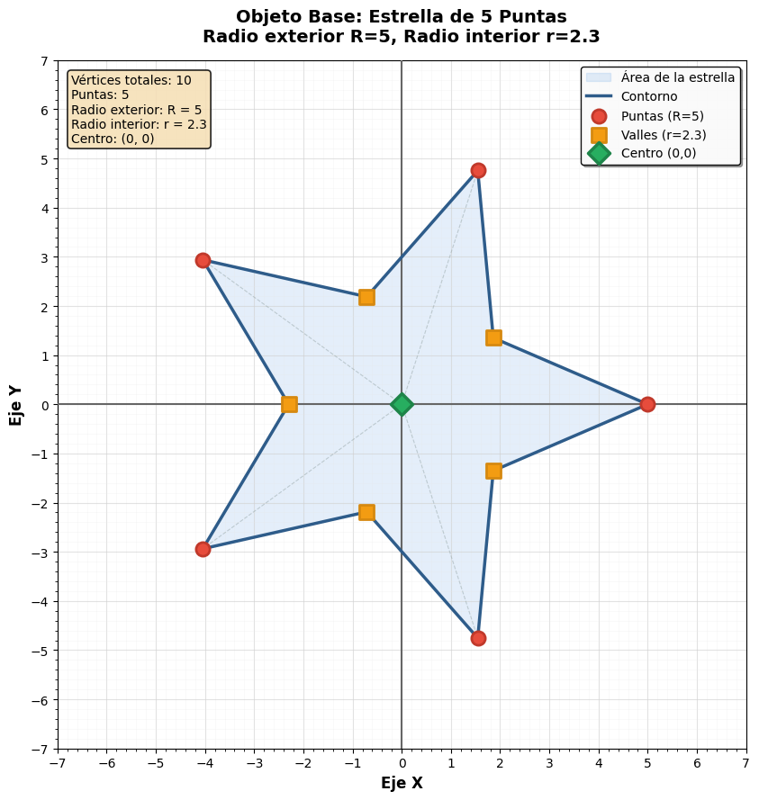

```python
# DEFINICIÓN DE FUNCIONES
def estrella(n_puntas=5, R=5, r=2.3):
    """
    Calcula los vértices de una estrella regular centrada en (0,0).

    Args:
        n_puntas (int): Número de puntas de la estrella.
        R (float): Radio del círculo circunscrito (puntas externas).
        r (float): Radio del círculo inscrito (valles internos).

    Returns:
        np.array: Matriz de forma (2, 2*n_puntas).
                  Fila 0 = coordenadas X, Fila 1 = coordenadas Y.
    """
    # 1. Generar ángulos: Se necesitan 2 vértices por punta (1 punta + 1 valle).
    # Se crea un array de ángulos de 0 a 2pi (360 grados).
    ang = np.linspace(0, 2*np.pi, 2*n_puntas, endpoint=False)

    # 2. Asignar radios alternados:
    # Si el índice 'i' es par (i%2==0), usa el Radio mayor (R).
    # Si el índice 'i' es impar, usa el radio menor (r).
    radios = np.array([R if i % 2 == 0 else r for i in range(2*n_puntas)])

    # 3. Conversión de coordenadas Polares a Cartesianas.
    x = radios * np.cos(ang)
    y = radios * np.sin(ang)

    # 4. Apilar verticalmente para tener una matriz limpia [[x1,x2...], [y1,y2...]]
    return np.vstack([x, y])

def configurar_plano(lim=8, paso=1):
    """
    Aplica estilo técnico al gráfico actual (similar a GeoGebra o papel milimetrado).

    Args:
        lim (int): Límite visual de los ejes (de -lim a +lim).
        paso (int): Frecuencia de las marcas (ticks) en los ejes.
    """
    ax = plt.gca() # Obtener el objeto de los ejes actuales (Get Current Axes)

    # Dibujar líneas centrales (Ejes X e Y) más oscuras
    plt.axhline(0, color='#666666', linewidth=1.5, zorder=3)
    plt.axvline(0, color='#666666', linewidth=1.5, zorder=3)

    # Definir el zoom del gráfico
    plt.xlim(-lim, lim)
    plt.ylim(-lim, lim)

    # Configurar las marcas numéricas en los ejes
    ticks = np.arange(-lim, lim + 1, paso)
    plt.xticks(ticks, fontsize=10)
    plt.yticks(ticks, fontsize=10)

    # Configurar la cuadrícula (Grid)
    # 'major': líneas principales (cada entero)
    plt.grid(True, which='major', color='#d0d0d0', linewidth=0.8, alpha=0.6, zorder=0)
    # 'minor': líneas secundarias (subdivisiones)
    plt.grid(True, which='minor', color='#e8e8e8', linewidth=0.4, alpha=0.4, zorder=0)
    ax.minorticks_on()

    # CRÍTICO: Mantiene la proporción 1:1 para que la estrella no se vea achatada
    ax.set_aspect('equal', adjustable='box')
    ax.set_facecolor('white') # Fondo blanco puro

# PARÁMETROS Y GENERACIÓN DE DATOS
n_puntas = 5    # Cantidad de picos
R = 5           # Radio externo (longitud de los picos)
r = 2.3         # Radio interno (profundidad de los valles)

# Llamada a la función generadora
obj = estrella(n_puntas=n_puntas, R=R, r=r)

# Cerrar el polígono:
# Matplotlib dibuja de punto A a punto B. Para cerrar la figura,
# repetimos el primer punto al final del array.
# obj[:, [0]] toma la primera columna y np.hstack la pega al final.
P = np.hstack([obj, obj[:, [0]]])

# VISUALIZACIÓN (PLOTTING)
plt.figure(figsize=(9, 9), facecolor='white')
ax = plt.gca()

# 1. Relleno (Área) - zorder bajo para que quede al fondo
plt.fill(P[0], P[1], color='#4A90E2', alpha=0.15, zorder=1, label='Área de la estrella')

# 2. Contorno (Línea) - zorder medio
plt.plot(P[0], P[1], color='#2E5C8A', linewidth=2.5, zorder=4, label='Contorno')

# 3. Separación de vértices para graficarlos distinto
# Slicing [::2] toma índices 0, 2, 4... (Puntas externas)
vertices_puntas = obj[:, ::2]
# Slicing [1::2] toma índices 1, 3, 5... (Valles internos)
vertices_valles = obj[:, 1::2]

# 4. Marcadores de las Puntas (Círculos rojos)
plt.scatter(vertices_puntas[0], vertices_puntas[1],
            s=120, c='#E74C3C', edgecolors='#C0392B', linewidths=2,
            zorder=5, label=f'Puntas (R={R})', marker='o')

# 5. Marcadores de los Valles (Cuadrados naranjas)
plt.scatter(vertices_valles[0], vertices_valles[1],
            s=120, c='#F39C12', edgecolors='#D68910', linewidths=2,
            zorder=5, label=f'Valles (r={r})', marker='s')

# 6. Centro Geométrico (Rombo verde)
plt.scatter(0, 0, s=150, c='#27AE60', edgecolors='#1E8449',
            linewidths=2.5, zorder=6, label='Centro (0,0)', marker='D')

# 7. Líneas Radiales (Guías visuales desde el centro a los vértices)
for i in range(0, obj.shape[1], 2):
    # Dibuja una línea punteada desde (0,0) hasta (x_punta, y_punta)
    plt.plot([0, obj[0, i]], [0, obj[1, i]],
             color='#95A5A6', linewidth=0.8, linestyle='--',
             alpha=0.5, zorder=2)

# ETIQUETADO Y FINALIZACIÓN
# Configurar ejes llamando a nuestra función auxiliar
configurar_plano(lim=7, paso=1)

# Títulos y etiquetas de ejes
plt.xlabel("Eje X", fontsize=12, fontweight='bold')
plt.ylabel("Eje Y", fontsize=12, fontweight='bold')
plt.title("Objeto Base: Estrella de 5 Puntas\n" +
          f"Radio exterior R={R}, Radio interior r={r}",
          fontsize=14, fontweight='bold', pad=15)

# Leyenda (Legend) con sombra y borde
plt.legend(loc='upper right', fontsize=10, framealpha=0.95,
           edgecolor='black', fancybox=True, shadow=True)

# Cuadro informativo flotante (Text Box)
textstr = (f'Vértices totales: {obj.shape[1]}\n'
           f'Puntas: {n_puntas}\n'
           f'Radio exterior: R = {R}\n'
           f'Radio interior: r = {r}\n'
           f'Centro: (0, 0)')

# Estilo del cuadro de texto
props = dict(boxstyle='round', facecolor='wheat', alpha=0.85,
             edgecolor='black', linewidth=1.2)

# Colocar texto. transform=ax.transAxes usa coordenadas relativas (0 a 1)
# en lugar de coordenadas de datos, para que el cuadro no se mueva al hacer zoom.
ax.text(0.02, 0.98, textstr, transform=ax.transAxes, fontsize=10,
        verticalalignment='top', bbox=props)

plt.tight_layout() # Ajusta márgenes automáticamente
plt.show()
```

## Rotación

La rotación es una transformación lineal que gira un objeto alrededor del origen por un ángulo θ (en sentido antihorario). Se representa mediante la matriz:

$$R(\theta) = \begin{bmatrix} \cos\theta & -\sin\theta \\ \sin\theta & \cos\theta \end{bmatrix}$$

Esta transformación preserva distancias y ángulos, por lo que el objeto mantiene su forma y tamaño, modificando únicamente su orientación. El centro de rotación permanece fijo en el origen (0, 0).

**Propiedades:**

- Preserva distancias (isometría)
- Preserva ángulos
- El determinante es 1 (preserva el área)
- Punto fijo: origen (0, 0)

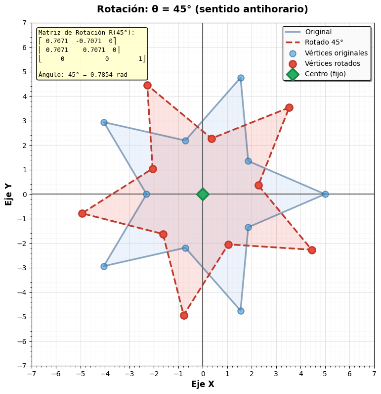

```
==================================================
MATRIZ DE ROTACIÓN - θ = 45°
==================================================
[[ 0.70710678 -0.70710678  0.        ]
 [ 0.70710678  0.70710678  0.        ]
 [ 0.          0.          1.        ]]

Determinante: 1.000000
(Det = 1 → preserva áreas, es una isometría)
```

```python
# LÓGICA MATEMÁTICA: TRANSFORMACIONES

def Rot(theta_grados):
    """
    Crea una matriz de transformación de rotación 2D (en coordenadas homogéneas).
    Args:
        theta_grados (float): Ángulo de rotación en grados.
                              (+) Antihorario, (-) Horario.
    Returns:
        np.array: Matriz 3x3 de rotación.
    """
    # NumPy trabaja con radianes, conversion obligatoria:
    t = np.radians(theta_grados)

    # Matriz de rotación estándar aumentada a 3x3
    # | cos  -sin   0 |
    # | sin   cos   0 |
    # |  0     0    1 |
    return np.array([
        [np.cos(t), -np.sin(t), 0],
        [np.sin(t),  np.cos(t), 0],
        [0,          0,         1]
    ])

def a_hom(P2xN):
    """
    Convierte coordenadas Cartesianas (2D) a Homogéneas (3D proyectivo).
    Agrega una fila de 1s al final de la matriz.
    Entrada: 2 filas (x, y) -> Salida: 3 filas (x, y, 1)
    """
    # np.ones crea una fila de unos del mismo ancho que los datos
    # np.vstack apila la matriz original sobre la fila de unos
    return np.vstack([P2xN, np.ones((1, P2xN.shape[1]))])

def de_hom(P3xN):
    """
    Convierte coordenadas Homogéneas a Cartesianas.
    Descarta la tercera fila (w).
    Entrada: 3 filas (x, y, w) -> Salida: 2 filas (x, y)
    """
    # Slicing [:2, :] toma filas 0 y 1, y todas las columnas
    return P3xN[:2, :]

# APLICACIÓN DE LA TRANSFORMACIÓN
# Definir el ángulo
theta = 45  # grados

# 1. Obtener la matriz de operación (A)
A = Rot(theta)

# 2. Pipeline de transformación:
#    Paso a: a_hom(obj) -> Convierte la estrella a [x, y, 1]
#    Paso b: A @ ...    -> Multiplica la matriz A por los puntos (Rotación)
#    Paso c: de_hom(...) -> Regresa a [x, y] para poder graficar
obj_rot = de_hom(A @ a_hom(obj))

# Cerrar la figura rotada para que el dibujo sea continuo (inicio = fin)
P_rot = np.hstack([obj_rot, obj_rot[:, [0]]])

# VISUALIZACIÓN
plt.figure(figsize=(9, 9), facecolor='white')
ax = plt.gca()

# --- DIBUJO DEL OBJETO ORIGINAL (FANTASMA) ---
# Se dibuja con alpha bajo (transparencia) para mostrar el "antes"
plt.fill(P[0], P[1], color='#4A90E2', alpha=0.10, zorder=1)
plt.plot(P[0], P[1], color='#2E5C8A', linewidth=2.5,
         label='Original', zorder=3, alpha=0.5) # alpha en borde también

# --- DIBUJO DEL OBJETO ROTADO (PRINCIPAL) ---
# Colores cálidos (rojos) para diferenciar la transformación
plt.fill(P_rot[0], P_rot[1], color='#E74C3C', alpha=0.15, zorder=2)
# Linestyle '--' (guiones) enfatiza que es el resultado
plt.plot(P_rot[0], P_rot[1], color='#C0392B', linewidth=2.5,
         linestyle='--', label=f'Rotado {theta}°', zorder=4)

# Vértices: azules para original, rojos para rotado
plt.scatter(obj[0, :], obj[1, :], s=80, c='#3498DB',
            edgecolors='#2E5C8A', linewidths=1.5, zorder=5,
            marker='o', alpha=0.6, label='Vértices originales')

plt.scatter(obj_rot[0, :], obj_rot[1, :], s=100,
            c='#E74C3C', edgecolors='#C0392B', linewidths=2,
            zorder=6, marker='o', label='Vértices rotados')

# Centro de rotación (Pivote)
plt.scatter(0, 0, s=150, c='#27AE60', edgecolors='#1E8449',
            linewidths=2.5, zorder=7, label='Centro (fijo)', marker='D')

# Configuración del entorno gráfico
configurar_plano(lim=7, paso=1)

# Etiquetas
plt.xlabel("Eje X", fontsize=12, fontweight='bold')
plt.ylabel("Eje Y", fontsize=12, fontweight='bold')
plt.title(f"Rotación: θ = {theta}° (sentido antihorario)",
          fontsize=14, fontweight='bold', pad=15)

plt.legend(loc='upper right', fontsize=10, framealpha=0.95,
           edgecolor='black', fancybox=True, shadow=True)

# --- CUADRO INFORMATIVO DE MATRIZ ---
# Muestra los valores numéricos reales de seno y coseno calculados
t_rad = np.radians(theta)
matriz_str = (f'Matriz de Rotación R({theta}°):\n'
              f'⎡{np.cos(t_rad):7.4f}  {-np.sin(t_rad):7.4f}  0⎤\n'
              f'⎢{np.sin(t_rad):7.4f}   {np.cos(t_rad):7.4f}  0⎥\n'
              f'⎣     0           0        1⎦\n'
              f'\nÁngulo: {theta}° = {t_rad:.4f} rad')

# boxstyle='round' redondea las esquinas, family='monospace' alinea los números
props = dict(boxstyle='round', facecolor='#ffffcc', alpha=0.9,
             edgecolor='black', linewidth=1.2)
ax.text(0.02, 0.98, matriz_str, transform=ax.transAxes, fontsize=9,
        verticalalignment='top', family='monospace', bbox=props)

plt.show()

# --- VERIFICACIÓN MATEMÁTICA EN CONSOLA ---
print("=" * 50)
print(f"MATRIZ DE ROTACIÓN - θ = {theta}°")
print("=" * 50)
print(A)
# El determinante de una rotación pura siempre debe ser 1
print(f"\nDeterminante: {np.linalg.det(A):.6f}")
print("(Det = 1 → preserva áreas, es una isometría)")
```

## Escalamiento

El escalamiento es una transformación lineal que modifica el tamaño de un objeto multiplicando sus coordenadas por factores de escala. Se representa mediante una matriz diagonal:

$$S(s_x, s_y) = \begin{bmatrix} s_x & 0 & 0 \\ 0 & s_y & 0 \\ 0 & 0 & 1 \end{bmatrix}$$

donde $s_x$ y $s_y$ son los factores de escala en los ejes x e y respectivamente.

Esta transformación puede:

- **Agrandar** el objeto si $s_x, s_y > 1$
- **Reducir** el objeto si $0 < s_x, s_y < 1$
- **Estirar** o **comprimir** asimétricamente si $s_x \neq s_y$
- **Reflejar** el objeto si $s_x < 0$ o $s_y < 0$

El origen (0, 0) permanece como punto fijo bajo esta transformación.

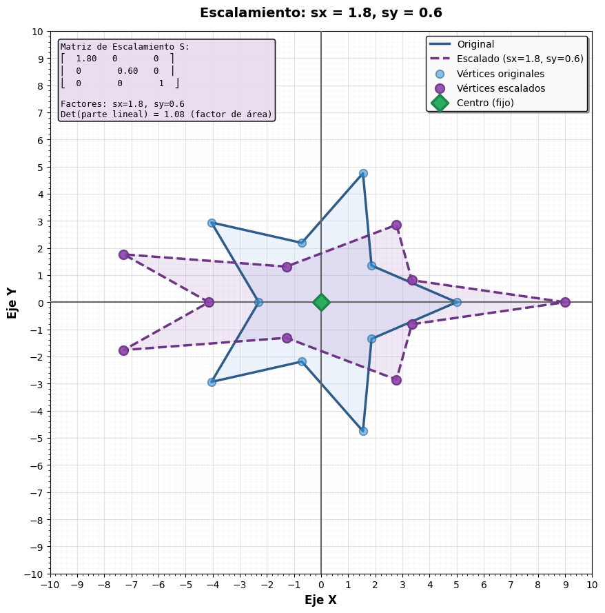

```
==================================================
MATRIZ DE ESCALAMIENTO - sx=1.8, sy=0.6
==================================================
[[1.8 0.  0. ]
 [0.  0.6 0. ]
 [0.  0.  1. ]]

Determinante (parte lineal 2×2): 1.080000
(Det = sx·sy = 1.8·0.6 → multiplica el área por 1.08)
```

```python
# LÓGICA MATEMÁTICA: ESCALAMIENTO
def Esc(sx, sy):
    """
    Crea la matriz de escalamiento en coordenadas homogéneas.

    Args:
        sx (float): Factor de escala en X (>1 estira, <1 contrae).
        sy (float): Factor de escala en Y (>1 estira, <1 contrae).

    Returns:
        np.array: Matriz diagonal 3x3.
    """
    # Matriz diagonal: Los valores fuera de la diagonal son 0.
    # | sx  0   0 |
    # | 0   sy  0 |
    # | 0   0   1 |
    return np.array([
        [sx, 0,  0],
        [0,  sy, 0],
        [0,  0,  1]
    ])

# APLICACIÓN DE LA TRANSFORMACIÓN
# Definir factores de escala
# sx = 1.8 -> Aumenta el ancho en un 80%
# sy = 0.6 -> Reduce la altura al 60% (aplastamiento)
sx, sy = 1.8, 0.6

# 1. Obtener la matriz S
S = Esc(sx, sy)

# 2. Pipeline de transformación:
#    a_hom(obj) -> Pasa a 3D [x, y, 1]
#    S @ ...    -> Multiplica (Escala cada coordenada independientemente)
#    de_hom(...) -> Regresa a 2D [x, y]
obj_esc = de_hom(S @ a_hom(obj))

# Cerrar la figura escalada para el dibujo
P_esc = np.hstack([obj_esc, obj_esc[:, [0]]])

# VISUALIZACIÓN
plt.figure(figsize=(9, 9), facecolor='white')
ax = plt.gca()

# --- OBJETO ORIGINAL (REFERENCIA) ---
plt.fill(P[0], P[1], color='#4A90E2', alpha=0.10, zorder=1)
plt.plot(P[0], P[1], color='#2E5C8A', linewidth=2.5,
         label='Original', zorder=3)

# --- OBJETO ESCALADO (RESULTADO) ---
# Se usa una paleta violeta/morada para diferenciar del azul (original) y rojo (rotación)
plt.fill(P_esc[0], P_esc[1], color='#8E44AD', alpha=0.12, zorder=2)
plt.plot(P_esc[0], P_esc[1], color='#6C3483', linewidth=2.5,
         linestyle='--', label=f'Escalado (sx={sx}, sy={sy})', zorder=4)

# Vértices: azules (original) vs morados (escalados)
plt.scatter(obj[0, :], obj[1, :], s=70, c='#3498DB',
            edgecolors='#2E5C8A', linewidths=1.3, zorder=5,
            marker='o', alpha=0.6, label='Vértices originales')

plt.scatter(obj_esc[0, :], obj_esc[1, :], s=85,
            c='#8E44AD', edgecolors='#6C3483', linewidths=1.8,
            zorder=6, marker='o', alpha=0.9, label='Vértices escalados')

# Centro (El origen (0,0) es el único punto que NO se mueve en un escalamiento puro)
plt.scatter(0, 0, s=150, c='#27AE60', edgecolors='#1E8449',
            linewidths=2.5, zorder=7, label='Centro (fijo)', marker='D')

# Configurar plano (zoom un poco más amplio, lim=10, porque la estrella se estiró)
configurar_plano(lim=10, paso=1)

# Etiquetas
plt.xlabel("Eje X", fontsize=12, fontweight='bold')
plt.ylabel("Eje Y", fontsize=12, fontweight='bold')
plt.title(f"Escalamiento: sx = {sx}, sy = {sy}",
          fontsize=14, fontweight='bold', pad=15)

plt.legend(loc='upper right', fontsize=10, framealpha=0.95,
           edgecolor='black', fancybox=True, shadow=True)

# --- CUADRO INFORMATIVO (MATRIZ Y ÁREA) ---

# Calculamos el determinante de la parte 2x2 superior izquierda.
# Esto nos dice cuánto cambió el área total de la figura.
det_lin = np.linalg.det(S[:2, :2])

matriz_str = (f'Matriz de Escalamiento S:\n'
              f'⎡{sx:6.2f}   0       0  ⎤\n'
              f'⎢  0     {sy:6.2f}   0  ⎥\n'
              f'⎣  0       0       1  ⎦\n'
              f'\nFactores: sx={sx}, sy={sy}\n'
              f'Det(parte lineal) = {det_lin:.2f} (factor de área)')

# Estilo morado claro para combinar con la figura
props = dict(boxstyle='round', facecolor='#e8daef', alpha=0.9,
             edgecolor='black', linewidth=1.2)
ax.text(0.02, 0.98, matriz_str, transform=ax.transAxes,
        fontsize=9, verticalalignment='top', family='monospace', bbox=props)

plt.tight_layout()
plt.show()

# --- ANÁLISIS EN CONSOLA ---
print("=" * 50)
print(f"MATRIZ DE ESCALAMIENTO - sx={sx}, sy={sy}")
print("=" * 50)
print(S)
print(f"\nDeterminante (parte lineal 2×2): {det_lin:.6f}")
print(f"(Det = sx·sy = {sx}·{sy} → multiplica el área por {det_lin:.2f})")
```

## Corte (Shear)

El corte (o cizallamiento) es una transformación lineal que "inclina" o "deforma" la figura sin cambiar su área. En coordenadas homogéneas, la matriz de corte horizontal es:

$$\text{Shear}_x(k) = \begin{bmatrix} 1 & k & 0 \\ 0 & 1 & 0 \\ 0 & 0 & 1 \end{bmatrix}$$

donde $k$ es el factor de corte.

**Efecto del corte horizontal:**

- La coordenada $x$ se modifica: $x' = x + k \cdot y$
- La coordenada $y$ permanece: $y' = y$
- El eje $x$ (donde $y = 0$) permanece fijo
- Puntos más alejados del eje $x$ se desplazan más

**Propiedades:**

- Preserva áreas (Det = 1)
- Transforma rectángulos en paralelogramos
- El origen (0, 0) permanece fijo

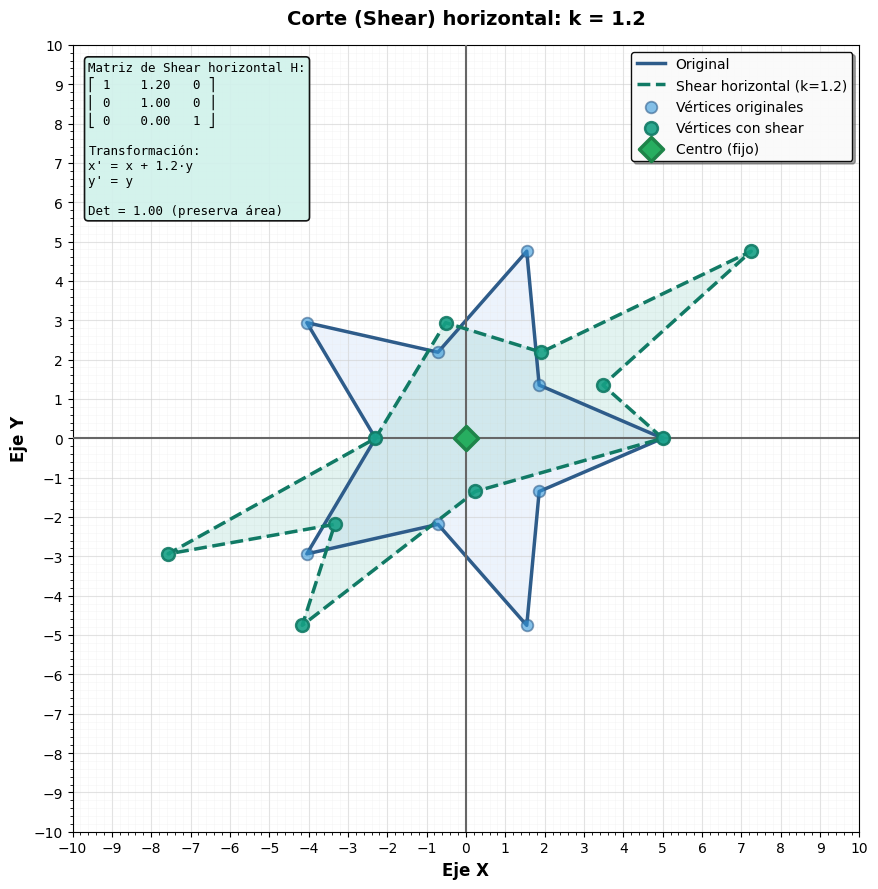

```
==================================================
MATRIZ DE SHEAR HORIZONTAL - k=1.2
==================================================
[[1.  1.2 0. ]
 [0.  1.  0. ]
 [0.  0.  1. ]]

Determinante (parte lineal 2×2): 1.000000
(Det = 1 → El área de la estrella NO ha cambiado, solo su forma)
```

```python
# LÓGICA MATEMÁTICA: CORTE (SHEAR)
def Shx(k):
    """
    Crea la matriz de Corte Horizontal (Shear X).
    El eje Y se mantiene fijo, el eje X se desplaza en función de Y.
    Args:
        k (float): Factor de corte.
                   k > 0: La parte superior se mueve a la derecha.
                   k < 0: La parte superior se mueve a la izquierda.
    """
    # Matriz Identidad modificada en la posición (0,1)
    # | 1  k  0 |
    # | 0  1  0 |
    # | 0  0  1 |
    return np.array([
        [1, k, 0],
        [0, 1, 0],
        [0, 0, 1]
    ])

def Shy(k):
    """
    Crea la matriz de Corte Vertical (Shear Y).
    El eje X se mantiene fijo, el eje Y se desplaza en función de X.
    """
    # Matriz Identidad modificada en la posición (1,0)
    # | 1  0  0 |
    # | k  1  0 |
    # | 0  0  1 |
    return np.array([
        [1, 0, 0],
        [k, 1, 0],
        [0, 0, 1]
    ])

# APLICACIÓN DE LA TRANSFORMACIÓN
# Definimos K (factor de fuerza del corte)
K = 1.2   # Valor sugerido: 1.2 (un corte bastante pronunciado)
k = K     # Asignación al parámetro local

# 1. Seleccionar matriz de Shear Horizontal
H = Shx(k)

# 2. Pipeline de transformación:
#    a_hom(obj) -> Coordenadas homogéneas
#    H @ ...    -> Multiplicación matricial (Aplica el corte)
#    de_hom(...) -> Retorno a cartesianas
obj_sh = de_hom(H @ a_hom(obj))

# Cerrar la figura deformada para graficar
P_sh = np.hstack([obj_sh, obj_sh[:, [0]]])

# VISUALIZACIÓN
plt.figure(figsize=(9, 9), facecolor='white')
ax = plt.gca()

# --- OBJETO ORIGINAL (FANTASMA) ---
plt.fill(P[0], P[1], color='#4A90E2', alpha=0.10, zorder=1)
plt.plot(P[0], P[1], color='#2E5C8A', linewidth=2.5,
         label='Original', zorder=3)

# --- OBJETO CON SHEAR (RESULTADO) ---
# Usamos tonos Verde Azulado (Teal) para diferenciar esta transformación
plt.fill(P_sh[0], P_sh[1], color='#16A085', alpha=0.12, zorder=2)
plt.plot(P_sh[0], P_sh[1], color='#117A65', linewidth=2.5,
         linestyle='--', label=f'Shear horizontal (k={k})', zorder=4)

# Vértices: Azul (Original) vs Teal (Shear)
plt.scatter(obj[0, :], obj[1, :], s=70, c='#3498DB',
            edgecolors='#2E5C8A', linewidths=1.3, zorder=5,
            marker='o', alpha=0.6, label='Vértices originales')

plt.scatter(obj_sh[0, :], obj_sh[1, :], s=85,
            c='#16A085', edgecolors='#117A65', linewidths=1.8,
            zorder=6, marker='o', alpha=0.9, label='Vértices con shear')

# Centro: El origen (0,0) es un "Punto Invariante" en el Shear
plt.scatter(0, 0, s=150, c='#27AE60', edgecolors='#1E8449',
            linewidths=2.5, zorder=7, label='Centro (fijo)', marker='D')

# Configurar plano (lim=10 para acomodar la deformación lateral)
configurar_plano(lim=10, paso=1)

# Etiquetas
plt.xlabel("Eje X", fontsize=12, fontweight='bold')
plt.ylabel("Eje Y", fontsize=12, fontweight='bold')
plt.title(f"Corte (Shear) horizontal: k = {k}",
          fontsize=14, fontweight='bold', pad=15)

plt.legend(loc='upper right', fontsize=10, framealpha=0.95,
           edgecolor='black', fancybox=True, shadow=True)

# --- CUADRO INFORMATIVO ---
det_lin = np.linalg.det(H[:2, :2])

matriz_str = (f'Matriz de Shear horizontal H:\n'
              f'⎡ 1   {k:5.2f}   0 ⎤\n'
              f'⎢ 0    1.00   0 ⎥\n'
              f'⎣ 0    0.00   1 ⎦\n'
              f'\nTransformación:\n'
              f"x' = x + {k}·y\n"
              f"y' = y\n"
              f'\nDet = {det_lin:.2f} (preserva área)')

# Estilo verde menta claro
props = dict(boxstyle='round', facecolor='#d1f2eb', alpha=0.92,
             edgecolor='black', linewidth=1.2)
ax.text(0.02, 0.98, matriz_str, transform=ax.transAxes,
        fontsize=9, verticalalignment='top', family='monospace', bbox=props)

plt.tight_layout()
plt.show()

# --- VALIDACIÓN EN CONSOLA ---
print("=" * 50)
print(f"MATRIZ DE SHEAR HORIZONTAL - k={k}")
print("=" * 50)
print(H)
print(f"\nDeterminante (parte lineal 2×2): {det_lin:.6f}")
print("(Det = 1 → El área de la estrella NO ha cambiado, solo su forma)")
```

## Traslación (usando coordenadas homogéneas)

La traslación es una transformación **afín** (no lineal) que desplaza todos los puntos del plano en una dirección específica. No es una transformación lineal en ℝ² porque no cumple $T(\mathbf{0}) = \mathbf{0}$.

Para representar traslaciones mediante multiplicación matricial, se utilizan **coordenadas homogéneas**, donde cada punto $(x, y)$ se representa como $(x, y, 1)$.

La matriz de traslación en coordenadas homogéneas es:

$$T(dx, dy) = \begin{bmatrix} 1 & 0 & dx \\ 0 & 1 & dy \\ 0 & 0 & 1 \end{bmatrix}$$

donde $dx$ y $dy$ son los desplazamientos en los ejes x e y respectivamente.

**Efecto de la traslación:**

- Coordenada x: $x' = x + dx$
- Coordenada y: $y' = y + dy$
- Todos los puntos se desplazan la misma distancia
- **No existe punto fijo** (excepto si $dx = dy = 0$)
- Preserva forma, tamaño y orientación

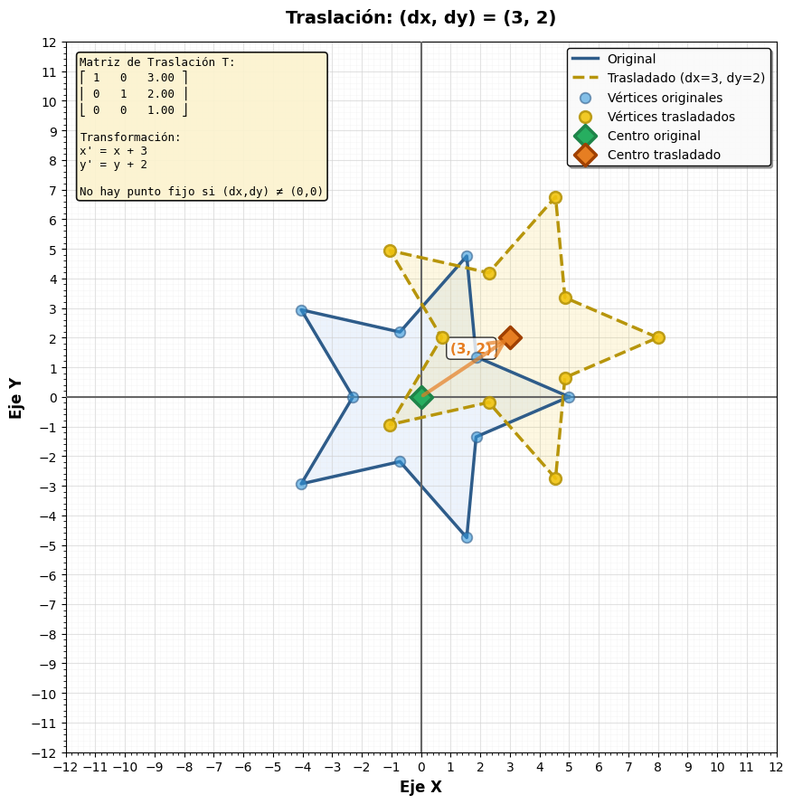

```
==================================================
MATRIZ DE TRASLACIÓN - dx=3, dy=2
==================================================
[[1 0 3]
 [0 1 2]
 [0 0 1]]

Vector de desplazamiento: (3, 2)
La traslación NO es una transformación lineal clásica
(El vector cero se mueve, por eso usamos coords homogéneas)
```

```python
import numpy as np
import matplotlib.pyplot as plt
from matplotlib.patches import FancyArrowPatch # Necesario para la flecha avanzada
# LÓGICA MATEMÁTICA: TRASLACIÓN
def Tras(dx, dy):
    """
    Crea la matriz de Traslación en coordenadas homogéneas.

    Args:
        dx (float): Desplazamiento en el eje X.
        dy (float): Desplazamiento en el eje Y.

    Returns:
        np.array: Matriz 3x3 donde la última COLUMNA contiene el desplazamiento.
    """
    # Matriz Identidad con la tercera columna modificada:
    # | 1  0  dx |
    # | 0  1  dy |
    # | 0  0  1  |
    return np.array([
        [1, 0, dx],
        [0, 1, dy],
        [0, 0, 1]
    ])

# APLICACIÓN DE LA TRANSFORMACIÓN
# Definir el vector de desplazamiento
dx, dy = 3, 2  # Mover 3 a la derecha, 2 hacia arriba

# 1. Crear matriz T
T = Tras(dx, dy)

# 2. Pipeline de transformación:
#    Notar que ahora el centro (0,0) TAMBIÉN cambiará de posición.
obj_tr = de_hom(T @ a_hom(obj))

# Cerrar la figura trasladada
P_tr = np.hstack([obj_tr, obj_tr[:, [0]]])

# VISUALIZACIÓN
plt.figure(figsize=(9, 9), facecolor='white')
ax = plt.gca()

# --- OBJETO ORIGINAL (FANTASMA) ---
plt.fill(P[0], P[1], color='#4A90E2', alpha=0.10, zorder=1)
plt.plot(P[0], P[1], color='#2E5C8A', linewidth=2.5,
         label='Original', zorder=3)

# --- OBJETO TRASLADADO (RESULTADO) ---
# Usamos tonos Amarillos/Dorados para diferenciar la traslación
plt.fill(P_tr[0], P_tr[1], color='#F1C40F', alpha=0.12, zorder=2)
plt.plot(P_tr[0], P_tr[1], color='#B7950B', linewidth=2.5,
         linestyle='--', label=f'Trasladado (dx={dx}, dy={dy})', zorder=4)

# Vértices:
plt.scatter(obj[0, :], obj[1, :], s=70, c='#3498DB',
            edgecolors='#2E5C8A', linewidths=1.3, zorder=5,
            marker='o', alpha=0.6, label='Vértices originales')

plt.scatter(obj_tr[0, :], obj_tr[1, :], s=85,
            c='#F1C40F', edgecolors='#B7950B', linewidths=1.8,
            zorder=6, marker='o', alpha=0.9, label='Vértices trasladados')

# --- CENTROS (EL ORIGEN SE MUEVE) ---
# Centro Original (0,0) en verde
plt.scatter(0, 0, s=150, c='#27AE60', edgecolors='#1E8449',
            linewidths=2.5, zorder=7, label='Centro original', marker='D')

# Centro Trasladado (dx, dy) en naranja
plt.scatter(dx, dy, s=150, c='#E67E22', edgecolors='#A04000',
            linewidths=2.5, zorder=7, label='Centro trasladado', marker='D')

# --- ELEMENTO EXTRA: FLECHA DE DESPLAZAMIENTO ---
# Dibuja una flecha desde el origen hasta el nuevo centro para visualizar el vector
arrow = FancyArrowPatch((0, 0), (dx, dy),
                        arrowstyle='->', mutation_scale=30, # mutation_scale = tamaño cabeza flecha
                        linewidth=3, color='#E67E22', alpha=0.7,
                        zorder=8)
ax.add_patch(arrow)

# Texto sobre la flecha (ubicado en el punto medio del trayecto)
ax.text(dx/2 - 0.5, dy/2 + 0.5, f'({dx}, {dy})',
        fontsize=11, color='#E67E22', fontweight='bold',
        bbox=dict(boxstyle='round', facecolor='white', alpha=0.8))

# Configurar plano (ampliado a lim=12 para que quepa el desplazamiento)
configurar_plano(lim=12, paso=1)

# Etiquetas y Título
plt.xlabel("Eje X", fontsize=12, fontweight='bold')
plt.ylabel("Eje Y", fontsize=12, fontweight='bold')
plt.title(f"Traslación: (dx, dy) = ({dx}, {dy})",
          fontsize=14, fontweight='bold', pad=15)

plt.legend(loc='upper right', fontsize=10, framealpha=0.95,
           edgecolor='black', fancybox=True, shadow=True)

# --- CUADRO INFORMATIVO ---
matriz_str = (f'Matriz de Traslación T:\n'
              f'⎡ 1   0  {dx:5.2f} ⎤\n'
              f'⎢ 0   1  {dy:5.2f} ⎥\n'
              f'⎣ 0   0   1.00 ⎦\n'
              f'\nTransformación:\n'
              f"x' = x + {dx}\n"
              f"y' = y + {dy}\n"
              f'\nNo hay punto fijo si (dx,dy) ≠ (0,0)')

# Estilo amarillo pálido
props = dict(boxstyle='round', facecolor='#fcf3cf', alpha=0.92,
             edgecolor='black', linewidth=1.2)
ax.text(0.02, 0.98, matriz_str, transform=ax.transAxes,
        fontsize=9, verticalalignment='top', family='monospace', bbox=props)

plt.tight_layout()
plt.show()

# --- CONSOLA ---
print("=" * 50)
print(f"MATRIZ DE TRASLACIÓN - dx={dx}, dy={dy}")
print("=" * 50)
print(T)
print(f"\nVector de desplazamiento: ({dx}, {dy})")
print("La traslación NO es una transformación lineal clásica")
print("(El vector cero se mueve, por eso usamos coords homogéneas)")
```

## Transformación compuesta

Se construye una transformación compuesta combinando varias transformaciones básicas. En coordenadas homogéneas, la composición se obtiene multiplicando las matrices en el orden en que se aplican.

**Importante:** La multiplicación matricial se lee de **derecha a izquierda**. Si queremos aplicar las transformaciones en el orden:

1. Rotación (R)
2. Escalamiento (S)
3. Corte (H)
4. Traslación (T)

La matriz compuesta se calcula como:

$$C = T \cdot H \cdot S \cdot R$$

donde cada matriz se multiplica por la izquierda de la anterior.

**Ventaja de la composición:** En lugar de aplicar 4 transformaciones sucesivas (4 multiplicaciones matriz-vector), se calcula una única matriz $C$ y se aplica una sola vez al objeto, obteniendo el mismo resultado con mayor eficiencia.

```
==================================================
MATRIZ COMPUESTA
C = T · H · S · R
==================================================
[[ 1.61220346 -0.93338095  3.        ]
 [ 0.42426407  0.42426407  2.        ]
 [ 0.          0.          1.        ]]

Parámetros usados:
Rotación: θ = 45°
Escalamiento: sx = 1.8, sy = 0.6
Shear: k = 0.8
Traslación: dx = 3, dy = 2
```

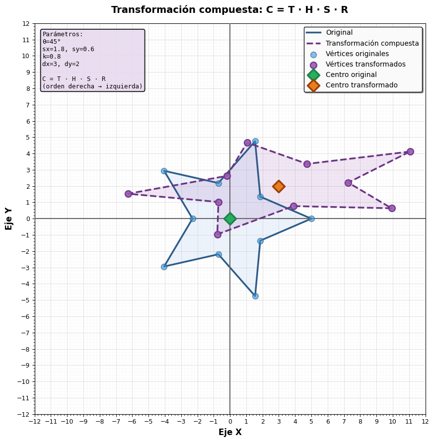

```python
# TRANSFORMACIÓN COMPUESTA
# Definición Matemática: C = T · H · S · R
# 1. DEFINICIÓN DE PARÁMETROS
# Se importan los valores globales definidos previamente en el flujo de trabajo.
# Estos valores determinan la intensidad de cada deformación.
theta = THETA       # Ángulo de rotación (45°)
sx, sy = SX, SY     # Factores de escala (1.8 ancho, 0.6 alto)
k = K               # Factor de distorsión/corte (0.8)
dx, dy = DX, DY     # Vector de desplazamiento (3, 2)

# 2. CONSTRUCCIÓN DE MATRICES INDIVIDUALES (3x3)
# Se generan las matrices básicas en coordenadas homogéneas.
R = Rot(theta)      # Matriz de Rotación (gira alrededor del origen)
S = Esc(sx, sy)     # Matriz de Escalamiento (estira/aplasta desde el origen)
H = Shx(k)          # Matriz de Shear (desliza eje X respecto al Y)
T = Tras(dx, dy)    # Matriz de Traslación (mueve todo el plano)

# 3. CÁLCULO DE LA MATRIZ COMPUESTA (NÚCLEO DEL CÓDIGO)
# La multiplicación matricial NO es conmutativa. El orden importa.
# Lectura de derecha a izquierda:
#   1º (R): El objeto gira.
#   2º (S): El objeto girado se escala.
#   3º (H): El objeto escalado se corta (shear).
#   4º (T): El resultado final se traslada.
C = T @ H @ S @ R

print("=" * 50)
print("MATRIZ COMPUESTA")
print("C = T · H · S · R")
print("=" * 50)
print(C)

# Desglose informativo para validar qué se está aplicando
print("\nParámetros usados:")
print(f"Rotación: θ = {theta}°")
print(f"Escalamiento: sx = {sx}, sy = {sy}")
print(f"Shear: k = {k}")
print(f"Traslación: dx = {dx}, dy = {dy}")

# APLICACIÓN DE LA TRANSFORMACIÓN
# Pipeline de procesamiento geométrico:
# 1. a_hom(obj): Convierte coordenadas cartesianas (2D) a homogéneas (3D, w=1).
# 2. C @ ...   : Aplica TODAS las transformaciones en una sola operación vectorial.
# 3. de_hom(...): Descarta la coordenada w y devuelve (x, y).
obj_c = de_hom(C @ a_hom(obj))

# Cierre de la figura:
# Se duplica el primer punto al final para que el contorno se dibuje cerrado.
P_c = np.hstack([obj_c, obj_c[:, [0]]])

# VISUALIZACIÓN
plt.figure(figsize=(9, 9), facecolor='white')
ax = plt.gca()

# --- ESTADO INICIAL (AZUL) ---
# Se dibuja tenue para servir como referencia ("fantasma").
plt.fill(P[0], P[1], color='#4A90E2', alpha=0.10, zorder=1)
plt.plot(P[0], P[1], color='#2E5C8A', linewidth=2.5,
         label='Original', zorder=3)

# --- ESTADO FINAL (VIOLETA) ---
# Se dibuja con colores distintos para resaltar el resultado de la composición.
plt.fill(P_c[0], P_c[1], color='#9B59B6', alpha=0.15, zorder=2)
plt.plot(P_c[0], P_c[1], color='#6C3483', linewidth=2.5,
         linestyle='--', label='Transformación compuesta', zorder=4)

# --- VÉRTICES ---
# Puntos azules: Geometría original
plt.scatter(obj[0, :], obj[1, :], s=70, c='#3498DB',
            edgecolors='#2E5C8A', linewidths=1.3,
            zorder=5, alpha=0.6, label='Vértices originales')

# Puntos violetas: Geometría transformada
plt.scatter(obj_c[0, :], obj_c[1, :], s=85,
            c='#9B59B6', edgecolors='#6C3483', linewidths=1.8,
            zorder=6, alpha=0.9, label='Vértices transformados')

# --- REFERENCIAS (CENTROS) ---
# Origen del sistema (0,0) - Inmóvil
plt.scatter(0, 0, s=150, c='#27AE60', edgecolors='#1E8449',
            linewidths=2.5, zorder=7, label='Centro original', marker='D')

# Cálculo del nuevo centro
# Transformamos el punto (0,0) usando la misma matriz C para ver dónde aterrizó.
# NOTA: Se usa [0,0] y [1,0] para extraer el valor escalar y evitar errores de array.
centro_transformado = de_hom(C @ np.array([[0], [0], [1]]))
cx, cy = float(centro_transformado[0,0]), float(centro_transformado[1,0])

# Nuevo centro - Naranja
plt.scatter(cx, cy, s=150, c='#E67E22', edgecolors='#A04000',
            linewidths=2.5, zorder=7, label='Centro transformado', marker='D')

# --- CONFIGURACIÓN DEL PLOT ---
configurar_plano(lim=12, paso=1)

# Etiquetas y metadatos
plt.xlabel("Eje X", fontsize=12, fontweight='bold')
plt.ylabel("Eje Y", fontsize=12, fontweight='bold')
plt.title("Transformación compuesta: C = T · H · S · R",
          fontsize=14, fontweight='bold', pad=15)

plt.legend(loc='upper right', fontsize=10, framealpha=0.95,
           edgecolor='black', fancybox=True, shadow=True)

# Cuadro de texto informativo
info_str = (
    f'Parámetros:\n'
    f'θ={theta}°\n'
    f'sx={sx}, sy={sy}\n'
    f'k={k}\n'
    f'dx={dx}, dy={dy}\n\n'
    f'C = T · H · S · R\n'
    f'(orden derecha → izquierda)'
)
props = dict(boxstyle='round', facecolor='#e8daef', alpha=0.92,
             edgecolor='black', linewidth=1.3)

# Posicionamiento relativo del texto (0.02, 0.98 = esquina superior izquierda)
ax.text(0.02, 0.98, info_str, transform=ax.transAxes,
        fontsize=9, verticalalignment='top', family='monospace', bbox=props)

plt.tight_layout()
plt.show()
```

## No conmutatividad (cambio de orden)

Una propiedad fundamental de las transformaciones lineales es que la multiplicación de matrices **no es conmutativa**, es decir:

$$A \cdot B \neq B \cdot A$$

en general. Esto significa que **el orden en que se aplican las transformaciones afecta el resultado final**.

Aunque ambas composiciones usan los mismos parámetros (mismo ángulo de rotación θ y mismo vector de traslación (dx, dy)), los resultados visuales son claramente diferentes, confirmando que $C_1 \neq C_2$.

```
============================================================
COMPARACIÓN DE CENTROS
============================================================
Centro Original: (0, 0)
Centro Orden 1:  (3.00, 2.00) -> (Coincide con dx, dy)
Centro Orden 2:  (5.01, 6.70) -> (Desplazado y rotado)
```

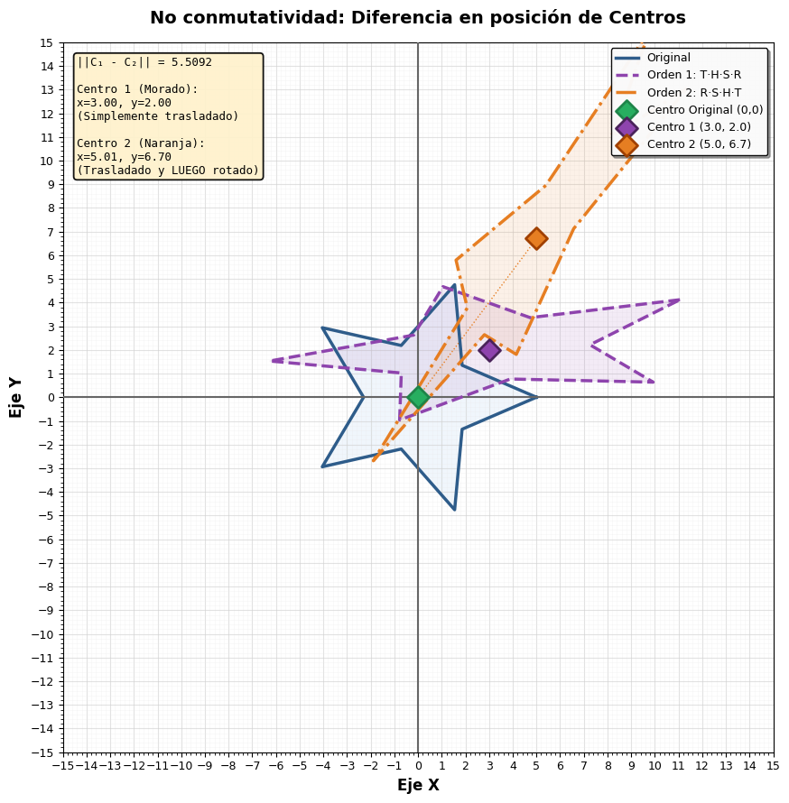

```python
# EXPERIMENTO: NO CONMUTATIVIDAD (CON CENTROS)
# 1. RECUPERAR PARÁMETROS
theta = THETA
sx, sy = SX, SY
k = K
dx, dy = DX, DY

# 2. GENERAR MATRICES
R = Rot(theta)
S = Esc(sx, sy)
H = Shx(k)
T = Tras(dx, dy)

# 3. DEFINIR LOS DOS ÓRDENES
# Orden 1: Estándar (T último)
C1 = T @ H @ S @ R
# Orden 2: Invertido (T primero)
C2 = R @ S @ H @ T

# 4. APLICACIÓN AL OBJETO
obj1 = de_hom(C1 @ a_hom(obj))
obj2 = de_hom(C2 @ a_hom(obj))

P1 = np.hstack([obj1, obj1[:, [0]]])
P2 = np.hstack([obj2, obj2[:, [0]]])

# --- NUEVO: CÁLCULO DE CENTROS ---
origin = np.array([[0], [0], [1]]) # El punto (0,0) en homogéneas

# Centro transformado por Orden 1
c1_p = C1 @ origin
cx1, cy1 = float(c1_p[0, 0]), float(c1_p[1, 0])

# Centro transformado por Orden 2
c2_p = C2 @ origin
cx2, cy2 = float(c2_p[0, 0]), float(c2_p[1, 0])

# Diferencia matemática
diff = np.linalg.norm(C1 - C2, 'fro')

print("=" * 60)
print(f"COMPARACIÓN DE CENTROS")
print("=" * 60)
print(f"Centro Original: (0, 0)")
print(f"Centro Orden 1:  ({cx1:.2f}, {cy1:.2f}) -> (Coincide con dx, dy)")
print(f"Centro Orden 2:  ({cx2:.2f}, {cy2:.2f}) -> (Desplazado y rotado)")

# VISUALIZACIÓN
plt.figure(figsize=(10, 9), facecolor='white')
ax = plt.gca()

# --- DIBUJO DE FIGURAS ---
# Original
plt.fill(P[0], P[1], color='#4A90E2', alpha=0.08, zorder=1)
plt.plot(P[0], P[1], color='#2E5C8A', linewidth=2.5, zorder=3, label='Original')

# Orden 1 (Morado)
plt.fill(P1[0], P1[1], color='#8E44AD', alpha=0.10, zorder=2)
plt.plot(P1[0], P1[1], color='#8E44AD', linewidth=2.5, linestyle='--',
         zorder=4, label='Orden 1: T·H·S·R')

# Orden 2 (Naranja)
plt.fill(P2[0], P2[1], color='#E67E22', alpha=0.10, zorder=2)
plt.plot(P2[0], P2[1], color='#E67E22', linewidth=2.5, linestyle='-.',
         zorder=4, label='Orden 2: R·S·H·T')

# --- NUEVO: VISUALIZACIÓN DE CENTROS ---

# 1. Centro Original (Verde)
plt.scatter(0, 0, s=150, c='#27AE60', edgecolors='#1E8449',
            linewidths=2, zorder=7, label='Centro Original (0,0)', marker='D')

# 2. Centro Orden 1 (Morado)
plt.scatter(cx1, cy1, s=150, c='#8E44AD', edgecolors='#4A235A',
            linewidths=2, zorder=8, label=f'Centro 1 ({cx1:.1f}, {cy1:.1f})', marker='D')

# 3. Centro Orden 2 (Naranja)
plt.scatter(cx2, cy2, s=150, c='#E67E22', edgecolors='#A04000',
            linewidths=2, zorder=8, label=f'Centro 2 ({cx2:.1f}, {cy2:.1f})', marker='D')

# Línea visual para entender la "órbita" del Orden 2
# Conecta el origen con el centro 2 para ver que fue rotado
plt.plot([0, cx2], [0, cy2], color='#E67E22', linestyle=':', linewidth=1, zorder=2)

# Configuración del plano
configurar_plano(lim=15, paso=1)

plt.title("No conmutatividad: Diferencia en posición de Centros",
          fontsize=14, fontweight='bold', pad=15)
plt.xlabel("Eje X", fontsize=12, fontweight='bold')
plt.ylabel("Eje Y", fontsize=12, fontweight='bold')

plt.legend(loc='upper right', fontsize=9, framealpha=0.95,
           edgecolor='black', fancybox=True, shadow=True)

# Cuadro informativo
info = (f'||C₁ - C₂|| = {diff:.4f}\n\n'
        f'Centro 1 (Morado):\n'
        f'x={cx1:.2f}, y={cy1:.2f}\n'
        f'(Simplemente trasladado)\n\n'
        f'Centro 2 (Naranja):\n'
        f'x={cx2:.2f}, y={cy2:.2f}\n'
        f'(Trasladado y LUEGO rotado)')

props = dict(boxstyle='round', facecolor='#fff2cc', alpha=0.93,
             edgecolor='black', linewidth=1.3)
ax.text(0.02, 0.98, info, transform=ax.transAxes,
        fontsize=9, verticalalignment='top', family='monospace', bbox=props)

plt.tight_layout()
plt.show()
```

## Conclusiones

En este proyecto se implementaron y visualizaron transformaciones geométricas en ℝ² utilizando el formalismo de **coordenadas homogéneas** y multiplicación matricial. Se aplicaron cuatro transformaciones fundamentales a un objeto base (estrella de cinco puntas):

1. **Rotación**: Preserva distancias y ángulos, manteniendo el origen como punto fijo.
2. **Escalamiento**: Modifica el tamaño del objeto según factores independientes en cada eje.
3. **Corte (shear)**: Deforma el objeto manteniendo un eje fijo; en este caso particular, el área se preserva al tener determinante igual a 1.
4. **Traslación**: Desplaza todos los puntos en una dirección específica, sin punto fijo.

Se construyó una **transformación compuesta** combinando las cuatro operaciones en una única matriz  
$C = T \cdot H \cdot S \cdot R$, demostrando que una composición secuencial de transformaciones es equivalente a una única multiplicación matricial, lo cual resulta más eficiente computacionalmente.

La **no conmutatividad** de la multiplicación matricial fue verificada experimentalmente al comparar dos composiciones con las mismas transformaciones aplicadas en distinto orden, confirmando que $C_1 \neq C_2$ cuando se altera la secuencia de operaciones.

Este trabajo demuestra cómo el **álgebra lineal** proporciona un marco matemático riguroso y eficiente para modelar transformaciones geométricas, con aplicaciones directas en:

- Gráficos por computadora y animación 3D
- Procesamiento de imágenes y visión computacional
- Robótica y control de sistemas mecánicos
- Realidad virtual y aumentada

El uso de coordenadas homogéneas permite unificar transformaciones lineales y afines bajo un mismo formalismo matricial, facilitando su implementación computacional, su composición mediante productos de matrices y su análisis matemático, lo cual constituye una herramienta fundamental en aplicaciones modernas de ingeniería y ciencias computacionales.

## Referencias

Strang, G. (2016). *Introduction to linear algebra* (5th ed.). Wellesley-Cambridge Press.

NumPy Developers. (s. f.). *NumPy documentation*. https://numpy.org/doc/stable/

Matplotlib Development Team. (s. f.). *Matplotlib documentation*. https://matplotlib.org/stable/